# Load Packages

```python
# !pip install emoji
import emoji
print(emoji.emojize('Keep Learning & Keep Winning! :revolving_hearts:'))
```

```
Keep Learning & Keep Winning! 💞
```

👅👅👅👅👅👅👅👅👅💪🏻💪🏻💪🏻💪🏻💪🏻💪🏻💪🏻💪🏻💪🏻💪🏻💪🏻💪🏻💪🏻💪🏻

```python
import numpy as np
import matplotlib.pyplot as plt
import scipy.stats as st
import seaborn as sns
from sklearn import linear_model
from sklearn.model_selection import cross_validate
from sklearn.model_selection import ShuffleSplit
from sklearn.metrics import r2_score # for R Squared
from sklearn.model_selection import train_test_split # for spliting the data
from sklearn.metrics import mean_squared_error # for MSE
from sklearn.linear_model import LogisticRegression
from sklearn import datasets
from sklearn.preprocessing import StandardScaler # to scale the data like in log linear scale
from sklearn.datasets import make_classification # to make dataset on classification
from sklearn.metrics import confusion_matrix
from math import sqrt
import urllib
from sklearn.neighbors import KNeighborsClassifier # for KNN
from sklearn import neighbors # for KNN
from sklearn import preprocessing # for ML preprocessing
import pandas as pd
from sklearn.tree import DecisionTreeClassifier # FOR dt
import pydotplus # for Images specially Decision tree with graphviz
from IPython.display import Image
from sklearn import tree # for Decision Tree
from sklearn.ensemble import RandomForestClassifier  # for Random forest
pd.options.display.float_format = '{:.2f}'.format #[numbers ] wil not appear in scientific form
```

# Set Theory:

**In order to understand Conditional Probability we first need to understand some basics of Set Theory**

## **Set:**

A Collection of numbers without repeating a single number more than a single time.  
Set is represented as A = {1,2,3,4,5}

Here A is a set.

## Union of Set

So Union is an Operation and it need operands and operands are sets.  
For Example, A = {1,2,3,4} B = {5,6,7,8}

A U B = {1,2,3,4,5,6,7,8}

## Intersection Of Set

Intersection contains only common elements between two sets  
For example: A = {1,2,3,4} B = {2,3}  
A ꓵ B = {2,3}

# Conditional Probability

It is a type of Probability that is calculated when another event which is given and has already occured  
For Example, Given that it rained yesterday, what is the probability of having rain today.

## Conditional Prob of Independent Events

- Independent Events: When there are two events and Occurence of one Event doesn't affect the probability of another event.
- The outcome of tossing the first coin cannot influence the outcome of tossing the second coin
- **P(A|B) = P(A) conditional probability is the probability of an event A occurring given that event B’s already occurred**

### PROBABILITY RULES OF INDEPENDENT EVENT

**1. RULE OF MULTIPLICATOION**  
The rule of multiplication is used when we want to find the probability of events occurring simultaneously Also known as **JointProbability**

**2. RULE OF ADDITION**  
The rule of addition allows determining the probability that at least one of the events occurs

# Prediction Probability

__How Good Our Prediction be will depend on 2 things__:

- how close max p(x) = 1 where p = probability
- how close our estimate of the probabilities are to the actual probabilities

[figure not shown]

# Bayes' rule (or theorem)

**METHODS THAT MODEL THE JOINT DISTRIBUTION OF Y AND PREDICTORS X ARE REFERRED TO AS GENERATIVE MODELS. nAIVE BAYES, LDA AND QDA [ quadratic discrimant analysis ]**

**Bayes’ theorem (alternatively Bayes’ law or Bayes’ rule) describes the probability of an event, based on prior knowledge of conditions that might be related to the event.**
For example, if a disease is related to age, then, using Bayes’ theorem, a person's age can be used to more accurately assess the probability that they have the disease, compared to the assessment of the probability of disease made without knowledge of the person’s age.
Bayes’ theorem is stated mathematically as the following equation:
$$ P(A\mid B)={\frac {P(B\mid A).P(A)}{P(B)}} $$
where $A$ and $B$ are events and $P(B)\neq0$.

- $P(A\mid B)$ is a conditional probability: the likelihood of event $A$ occurring given that $B$ is true and has occured.
- $P(B\mid A)$ is also a conditional probability: the likelihood of event $B$ occurring given that $A$ is true and has occured.
- $P(A)$ and $P(B)$ are the probabilities of observing $A$ and $B$ independently of each other; this is known as the marginal probability.

## Example for Bayes

```python
import numpy as np
import matplotlib.pyplot as plt
import scipy.stats as st
import seaborn as sns
```

## Sensitivity and Specificity

__The ideal test should be able to deliver results with 100% sensitivity and 100% specificity. However, in a practical application, it is difficult to achieve this.__  
**specificity is very important in medical testing and chemical testing. In medical testing, confirming that a person does not have the disease is more important than detecting whether a person has it**

We will write a custom function which accepts the test capabilities and the prior knowledge of drug user percentage as input and produces the output probability of a test-taker being an user based on a positive result.

The Bayes' rule based calculation is given by the following equation,

$$ P(\text{User}|+)=\frac{P(+|\text{User}).P(\text{User})}{P(+)}\\ = \frac{P(+|\text{User}).P(\text{User})}{P(+|\text{User}).P(\text{User})+P(+|\text{Non-user}).P(\text{Non-user})} $$

Here,

$P(\text{User}) = \text{Prevelance rate}$  
π  
$P(\text{Non-user}) = 1-\text{Prevelance rate}$  
$P(+|\text{User})=\text{Sensitivity}$  
$P(-|\text{Non-user})=\text{Specificity}$  
$P(+|\text{Non-user})=1-\text{Specificity}$

```python
def drug_user(prob_th=0.5,sensitivity=0.85,specificity=0.90,prevelance=0.02,verbose=True):
    """
    """
    p_user = prevelance
    p_non_user = 1-prevelance
    p_pos_user = sensitivity
    p_neg_user = specificity
    p_pos_non_user = 1-specificity

    num = p_pos_user*p_user
    den = p_pos_user*p_user+p_pos_non_user*p_non_user

    prob = num/den

    if verbose:
        if prob > prob_th:
            print("The test-taker could be an user")
        else:
            print("The test-taker may not be an user")

    return prob

# Calculate Probability
p = drug_user(sensitivity=0.85,specificity=0.90,prevelance=0.02) # Prevelance is current % or current state
print("Probability of the test-taker being a drug user is:",round(p,3))
```

```
The test-taker may not be an user
Probability of the test-taker being a drug user is: 0.148
```

Even with a test that is 85% correct for catching positive cases, and 90% correct for rejecting negative cases, the true probability of being a drug-user with a positive result is only 14.8%!

If you look at the computations, this is because of extremely low prevelance rate. The number of false positives outweighs the number of true positives.

### Conclusion

This conclusion can be intuitively derived from the fact that the main issue with having low probability is the low prevelance rate. Therefore, catching non-users correctly (i.e. improving specificity) is the area where we should focus on because they are much larger in numbers that the user.

Negative examples >> Positive examples in this problem. Therefore, True Negative performance of the test should be excellent.

## Naive Bayes

Step 1: Calculate the prior probability for given class labels  
Step 2: Find Likelihood probability with each attribute for each class  
Step 3: Put these value in Bayes Formula and calculate posterior probability  
Step 4: See which class has a higher probability, given the input belongs to the higher probability class

Naive bayes is called **NAIVE** because it is built with some assumption that may or may not turn out to be correct !!!

- **A posterior probability is the probability of assigning observations or data to specific groups. For example for a car sale if we know a specific model previously has been purchased 60% by males and 40% by feamles**
- **A prior probability on the other hand is the probability that an observation will fall into a group before you collect the data**

```python
#Import scikit-learn dataset library
from sklearn import datasets

#Load dataset
wine = datasets.load_wine()
```

```python
# print the names of the 13 features
print( "Features:",wine.feature_names)
```

```
Features: ['alcohol', 'malic_acid', 'ash', 'alcalinity_of_ash', 'magnesium', 'total_phenols', 'flavanoids', 'nonflavanoid_phenols', 'proanthocyanins', 'color_intensity', 'hue', 'od280/od315_of_diluted_wines', 'proline']
```

```python
print ("Labels: " , wine.target_names)
```

```
Labels:  ['class_0' 'class_1' 'class_2']
```

```python
wine.data.shape
wine.data[0:5]
```

```
array([[1.423e+01, 1.710e+00, 2.430e+00, 1.560e+01, 1.270e+02, 2.800e+00,
        3.060e+00, 2.800e-01, 2.290e+00, 5.640e+00, 1.040e+00, 3.920e+00,
        1.065e+03],
       [1.320e+01, 1.780e+00, 2.140e+00, 1.120e+01, 1.000e+02, 2.650e+00,
        2.760e+00, 2.600e-01, 1.280e+00, 4.380e+00, 1.050e+00, 3.400e+00,
        1.050e+03],
       [1.316e+01, 2.360e+00, 2.670e+00, 1.860e+01, 1.010e+02, 2.800e+00,
        3.240e+00, 3.000e-01, 2.810e+00, 5.680e+00, 1.030e+00, 3.170e+00,
        1.185e+03],
       [1.437e+01, 1.950e+00, 2.500e+00, 1.680e+01, 1.130e+02, 3.850e+00,
        3.490e+00, 2.400e-01, 2.180e+00, 7.800e+00, 8.600e-01, 3.450e+00,
        1.480e+03],
       [1.324e+01, 2.590e+00, 2.870e+00, 2.100e+01, 1.180e+02, 2.800e+00,
        2.690e+00, 3.900e-01, 1.820e+00, 4.320e+00, 1.040e+00, 2.930e+00,
        7.350e+02]])
```

```python
from sklearn.model_selection import train_test_split
X_train, X_test, y_train, y_test = train_test_split(wine.data, wine.target, test_size=0.3,random_state=109)
# 70% training and 30% test
```

```python
#Import Gaussian Naive Bayes model
from sklearn.naive_bayes import GaussianNB

#Create a Gaussian Classifier
gnb = GaussianNB()

# #Train the model using the training sets
gnb.fit(X_train, y_train)

# #Predict the response for test dataset
y_pred = gnb.predict(X_test)
```

**Gaussian Distribution** is same as **Normal Distribution** where mean, mode and median are the same,and The skewness and the kurtosis are zero

```python
#Import scikit-learn metrics module for accuracy calculation
from sklearn import metrics

# Model Accuracy, how often is the classifier correct?
print("Accuracy:",metrics.accuracy_score(y_test, y_pred))
```

```
Accuracy: 0.9074074074074074
```

# Linear Regression

1. In regression, the intercept only model has no independent variables. Thus, it predicts that the best estimate of the dependent variable for each subject is the overall mean. Often, the use of the intercept only model is as a comparison to other models that do include independent variables
2. The intercept (often labeled the constant) is the expected mean value of Y when all X=0
   - If X never equals 0, then the intercept has no intrinsic meaning. In scientific research, the purpose of a regression model is to understand the relationship between predictors and the response
   - The formula for regression can be xpressed in 2 ways [is the same but represented in 2 ways majorly]:  
     **Y = a + bX + error, where the slope of the line is b, while a is the intercept.**
3. The slope of the line represents the change of the data plotted on the y-axis to the change of the data plotted on the x-axis
4. __Coefficient = A number used to multiply a variable.Example: 6z means 6 times z, and "z" is a variable, so 6 is a coefficient__

[figure not shown]

### Measures of Performance

1. Mean Squared Error [MSE]: first we take the diff in actual vs predicted, square it and then take the average
2. R-Sq.**[Coefficient Of Determination]** : Explains how much total variance in the data is explained by the model
3. Adjusted R Sqr: When we add more independent variables into the model, R sqr increases irrespective of whether the additional variables improve the model.
   - __Hence Adjusted R Square penalises the model if the new variable doesnt fit the model__
4. Mallow's Cp: used in selecting the best regression model, its value should be small and close to the number of independent variables

### Multi-Collinearity

A phenomenon in which 2 or more predictor variables are in mutiple regression model are highly correlated.  
This can be detected using:  
1- Correlation Matrix  
2- VIF {Variation Inflation Factor} - **if none of the independt var are correlated then VIF will be 1**

### Outlier Detection

Cook's Distance is used to estimate the influence of data points in linear regression

### Basic Example

```python
import numpy as np
import pandas as pd
import matplotlib.pyplot as plt
import seaborn as sns
from sklearn import linear_model
from sklearn.model_selection import cross_validate
from sklearn.model_selection import ShuffleSplit
```

```python
data= pd.read_csv("Boston_housing.csv", sep=",")
data.head(5)
#medv is the dependent var i.e. median price in boston of owner occupied houses
```

|  | crim | zn | indus | chas | nox | rm | age | dis | rad | tax | ptratio | b | lstat | medv |
| --- | --- | --- | --- | --- | --- | --- | --- | --- | --- | --- | --- | --- | --- | --- |
| 0 | 0.01 | 18.00 | 2.31 | 0 | 0.54 | 6.58 | 65.20 | 4.09 | 1 | 296 | 15.30 | 396.90 | 4.98 | 24.00 |
| 1 | 0.03 | 0.00 | 7.07 | 0 | 0.47 | 6.42 | 78.90 | 4.97 | 2 | 242 | 17.80 | 396.90 | 9.14 | 21.60 |
| 2 | 0.03 | 0.00 | 7.07 | 0 | 0.47 | 7.18 | 61.10 | 4.97 | 2 | 242 | 17.80 | 392.83 | 4.03 | 34.70 |
| 3 | 0.03 | 0.00 | 2.18 | 0 | 0.46 | 7.00 | 45.80 | 6.06 | 3 | 222 | 18.70 | 394.63 | 2.94 | 33.40 |
| 4 | 0.07 | 0.00 | 2.18 | 0 | 0.46 | 7.15 | 54.20 | 6.06 | 3 | 222 | 18.70 | 396.90 | 5.33 | 36.20 |

```python
# Bacis Info on Dataset :
data.info()
```

```
<class 'pandas.core.frame.DataFrame'>
RangeIndex: 506 entries, 0 to 505
Data columns (total 14 columns):
 #   Column   Non-Null Count  Dtype
---  ------   --------------  -----
 0   crim     506 non-null    float64
 1   zn       506 non-null    float64
 2   indus    506 non-null    float64
 3   chas     506 non-null    int64
 4   nox      506 non-null    float64
 5   rm       506 non-null    float64
 6   age      506 non-null    float64
 7   dis      506 non-null    float64
 8   rad      506 non-null    int64
 9   tax      506 non-null    int64
 10  ptratio  506 non-null    float64
 11  b        506 non-null    float64
 12  lstat    506 non-null    float64
 13  medv     506 non-null    float64
dtypes: float64(11), int64(3)
memory usage: 55.5 KB
```

```python
data.describe()
```

|  | crim | zn | indus | chas | nox | rm | age | dis | rad | tax | ptratio | b | lstat | medv |
| --- | --- | --- | --- | --- | --- | --- | --- | --- | --- | --- | --- | --- | --- | --- |
| count | 506.00 | 506.00 | 506.00 | 506.00 | 506.00 | 506.00 | 506.00 | 506.00 | 506.00 | 506.00 | 506.00 | 506.00 | 506.00 | 506.00 |
| mean | 3.61 | 11.36 | 11.14 | 0.07 | 0.55 | 6.28 | 68.57 | 3.80 | 9.55 | 408.24 | 18.46 | 356.67 | 12.65 | 22.53 |
| std | 8.60 | 23.32 | 6.86 | 0.25 | 0.12 | 0.70 | 28.15 | 2.11 | 8.71 | 168.54 | 2.16 | 91.29 | 7.14 | 9.20 |
| min | 0.01 | 0.00 | 0.46 | 0.00 | 0.39 | 3.56 | 2.90 | 1.13 | 1.00 | 187.00 | 12.60 | 0.32 | 1.73 | 5.00 |
| 25% | 0.08 | 0.00 | 5.19 | 0.00 | 0.45 | 5.89 | 45.02 | 2.10 | 4.00 | 279.00 | 17.40 | 375.38 | 6.95 | 17.02 |
| 50% | 0.26 | 0.00 | 9.69 | 0.00 | 0.54 | 6.21 | 77.50 | 3.21 | 5.00 | 330.00 | 19.05 | 391.44 | 11.36 | 21.20 |
| 75% | 3.68 | 12.50 | 18.10 | 0.00 | 0.62 | 6.62 | 94.07 | 5.19 | 24.00 | 666.00 | 20.20 | 396.23 | 16.96 | 25.00 |
| max | 88.98 | 100.00 | 27.74 | 1.00 | 0.87 | 8.78 | 100.00 | 12.13 | 24.00 | 711.00 | 22.00 | 396.90 | 37.97 | 50.00 |

```python
# Load the Boston housing dataset
prices = data['medv']
features = data.drop(['medv','zn','crim','indus','chas','nox','age','rad','dis','b','tax'], axis='columns')
# Success,

features.info()
features.columns

#RM = average number of rooms among homes in the neighborhood.
#LSTAT' is the percentage of homeowners in the neighborhood considered "lower class" (working poor)
#PTRATIO' is the ratio of students to teachers in primary and secondary schools in the neighborhood
```

```
<class 'pandas.core.frame.DataFrame'>
RangeIndex: 506 entries, 0 to 505
Data columns (total 3 columns):
 #   Column   Non-Null Count  Dtype
---  ------   --------------  -----
 0   rm       506 non-null    float64
 1   ptratio  506 non-null    float64
 2   lstat    506 non-null    float64
dtypes: float64(3)
memory usage: 12.0 KB
```

```
Index(['rm', 'ptratio', 'lstat'], dtype='object')
```

```python
#EDA
# TODO: Minimum price of the data
minimum_price = np.min(prices)
minimum_price

maximum_price = prices.max()
# mean_price = prices.mean()
prices.describe()
```

```
count   506.00
mean     22.53
std       9.20
min       5.00
25%      17.02
50%      21.20
75%      25.00
max      50.00
Name: medv, dtype: float64
```

```python
# There are other statistics you can calculate too like quartiles
first_quartile = np.percentile(prices, 25)
third_quartile = np.percentile(prices, 75)
inter_quartile = third_quartile - first_quartile
inter_quartile
```

```
7.975000000000001
```

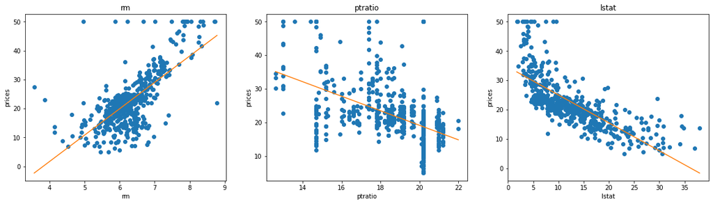

```python
import matplotlib.pyplot as plt
plt.figure(figsize=(20, 5))
# i: index
for i, col in enumerate(features.columns):
    # 3 plots here hence 1, 3
    plt.subplot(1, 3, i+1)
    x = data[col]
    y = prices
    plt.plot(x, y, 'o')
    # Create regression line
    plt.plot(np.unique(x), np.poly1d(np.polyfit(x, y, 1))(np.unique(x)))
    plt.title(col)
    plt.xlabel(col)
    plt.ylabel('prices')
    plt.ylabel('prices')
```

```python
from sklearn.metrics import r2_score
def performance_metric(y_true, y_predict):
    """ Calculates and returns the performance score between
        true and predicted values based on the metric chosen. """

    # TODO: Calculate the performance score between 'y_true' and 'y_predict'
    score = r2_score(y_true, y_predict)

    # Return the score
    return score
```

```python
# TODO: Import 'train_test_split'
from sklearn.model_selection import cross_validate
from sklearn.model_selection import train_test_split

# TODO: Shuffle and split the data into training and testing subsets
X_train, X_test, y_train, y_test = train_test_split(features, prices, test_size=0.2, random_state=10)

# Success
print ("Training and testing split was successful")
```

```
Training and testing split was successful
```

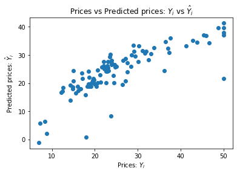

```python
from sklearn.linear_model import LinearRegression
lm = LinearRegression()
lm.fit(X_train, y_train)

Y_pred = lm.predict(X_test)
plt.scatter(y_test, Y_pred)

plt.xlabel("Prices: $Y_i$")
plt.ylabel("Predicted prices: $\hat{Y}_i$")
plt.title("Prices vs Predicted prices: $Y_i$ vs $\hat{Y}_i$")
```